# 景観保全と建築物の高さ制御

岩田真一郎（神奈川大学経済学部）

2025-07-18作成，2025-07-28改訂

［PDF形式：288KB］

国立市は，図1のようにJR国立駅を中心に，大学通り，富士見通り，旭通りが放射状に広がる学園都市です．日本経済新聞（2018）には，この景観を保全したいという国立市住民の強い思いが紹介されています．

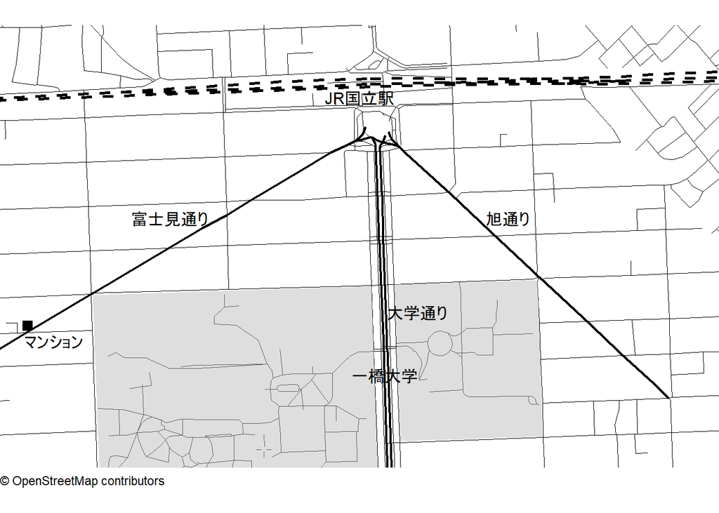

図1：JR国立駅周辺

# 1 高層税と補償

[外部性](https://ja.wikipedia.org/wiki/%E5%A4%96%E9%83%A8%E6%80%A7)を**内部化**する手段の経済学的な典型手法が**ピグー税**です．内部化とは，負の外部性を，税を通じて価格に反映させ，市場内部に取り入れることをいいます．この方法は考案した研究者[ピグー](https://ja.wikipedia.org/wiki/%E3%82%A2%E3%83%BC%E3%82%B5%E3%83%BC%E3%83%BB%E3%82%BB%E3%82%B7%E3%83%AB%E3%83%BB%E3%83%94%E3%82%B0%E3%83%BC)（ケンブリッジ大学）を称えて，ピグー税とよばれます．ここでは，高さを制御するため，これを「高層税」とよび，話を進めます．

図2は，[住宅価格と住宅政策](https://shinichiro-iwata.github.io/lecture-notes-urban-econ/housing-price-and-policy.html)の「4 政府介入 （4）負の外部性と土地利用規制」の図8の再掲です．そこでの説明を思い出してみましょう．図2の建物開発において，市場均衡は需要曲線D<sub>0</sub>と供給曲線S<sub>0</sub>の交点Cで決定され，建物の高さはH<sub>0</sub>単位に達します．このとき，消費者余剰は面積ACP<sub>0</sub>に，生産者余剰は面積ICP<sub>0</sub>になります．建物の取引は購入者（消費者）とデベロッパー（生産者）の間で行われます．ただし，建物は1単位高くなるごとに，取引に参加していない周辺住民に対してzの大きさの負の外部性を発生するとしましょう．供給曲線S<sub>1</sub>はこのzを含んだ供給曲線になります．建物の高さがH<sub>0</sub>単位のとき，周辺住民は，面積P<sub>0</sub>QCI（供給曲線S<sub>1</sub>とS<sub>0</sub>の差zに建物の高さH<sub>0</sub>を掛け合わせた面積）の外部費用を被ります．社会的余剰は，消費者と生産者の余剰の合計から，周辺住民の外部費用を差し引いた値になるため，面積ABP<sub>0</sub> – BQCになります．

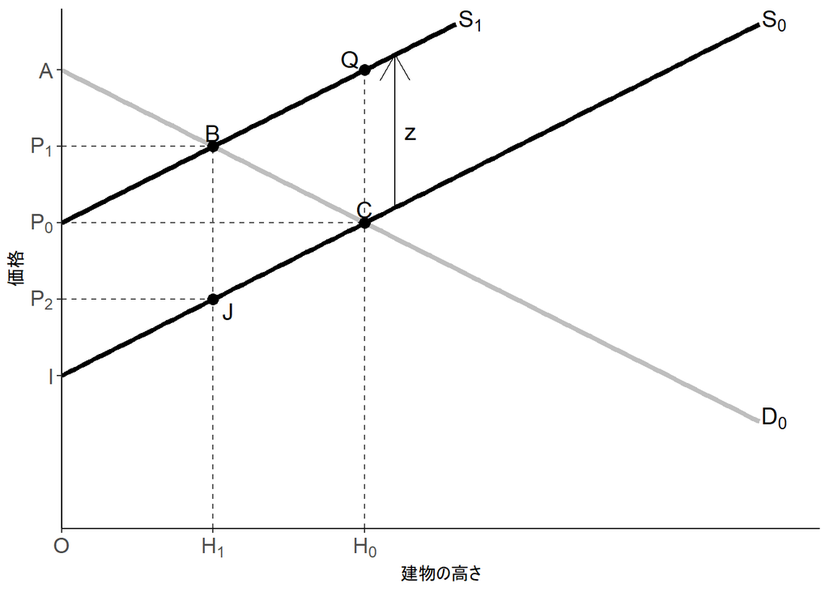

図2：負の外部性と高層税の効果

# 2 景観権とコースの定理

地方自治体が関与せず，利害関係者同士の自発的な取引によっても，B点を達成する方法があります。この考え方を示したのが，[コース](https://ja.wikipedia.org/wiki/%E3%83%AD%E3%83%8A%E3%83%AB%E3%83%89%E3%83%BB%E3%82%B3%E3%83%BC%E3%82%B9)（シカゴ大学）です．ただし，そのためには，景観に影響を及ぼす建物の高さを決定する権利を設定する必要があります。本稿では，この権利を「景観権」とよぶことにします．

景観権が開発による影響を受ける周辺住民に与えられたとしましょう．この場合，周辺住民は建物の高さを図3のゼロにすることが合理的と考えられます．なぜなら，そうすることによって外部費用を負わずにすみ，余剰をゼロに保てるからです．一方で，デベロッパーと購入者は，建物を開発しなければ余剰を得ることができません．たとえば，建物の高さをM単位にした場合，デベロッパーと購入者が得る余剰の合計は面積AEGIになります．しかし，このとき周辺住民は面積P<sub>0</sub>FGIに相当する外部費用を被るため，景観権を盾に開発に反対するはずです．そこで，開発受益者（デベロッパーと購入者）が周辺住民に対して外部費用をすべて補償すると提案したとしましょう．このとき，周辺住民は建物の高さがゼロの場合と同じ余剰，すなわち無差別の状態に置かれます．一方で，開発受益者は補償を支払っても，なお面積AEFP<sub>0</sub>に相当する余剰を得られるため，建物の高さがゼロの場合よりも状況が改善します．この取引の結果，建物の高さはMになります．

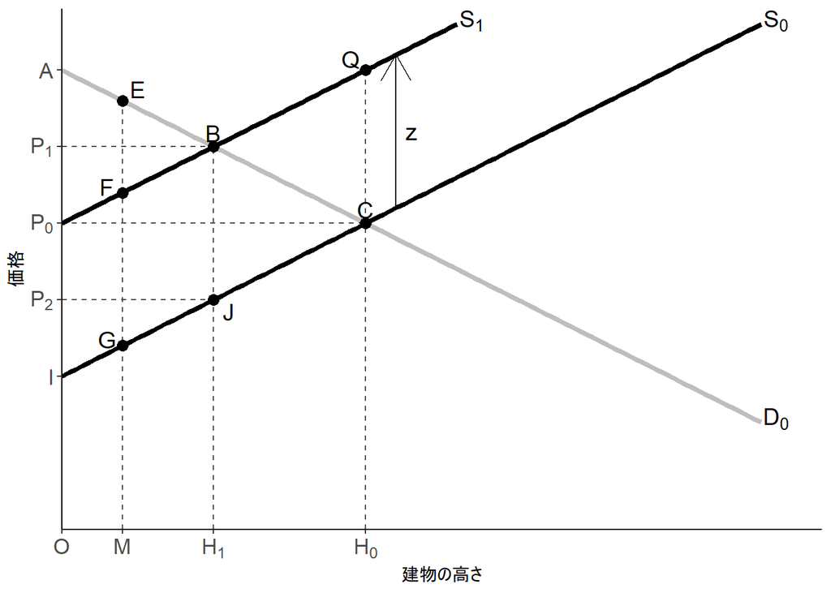

図3：負の外部性と景観権（周辺住民に付与）

それでは，建物は最終的にどこまで高くなるでしょうか？その答えは，社会的余剰を最大化する高さH<sub>1</sub>になります．このとき，開発受益者は周辺住民の外部費用（面積P<sub>0</sub>BJI）を補償しても，面積AEFP<sub>0</sub>を超える面積ABP<sub>0</sub>の余剰を得ることができます．一方，周辺住民は外部費用を補償されるため，建物の高さがH<sub>1</sub>であっても余剰はゼロのままになります．したがって，景観権を周辺住民に与えることは，高層税と補償の組み合わせ同様に，周辺住民の不満を抑えながら建築物を開発することを可能とします．

興味深いことに，最適な高さを達成するだけであれば，景観権を開発受益者に与えても実現できます．この場合，開発受益者は建物の高さを市場均衡で達成される図4のH<sub>0</sub>にすることが合理的です．なぜなら，これによって開発受益者の余剰が面積ACIと最大になるからです．一方，周辺住民は，建物の高さを低くしなけらば外部費用が拡大していきます．たとえば，建物の高さをN単位に低くしてもらえれば，周辺住民は外部費用を面積RQCUだけ減らすことができます．しかし，その場合，開発受益者の余剰は面積TCUだけ減るため，開発受益者は建物の高さを下げることに反対するはずです．そこで周辺住民が開発受益者に対し，この余剰の減少分をすべて補償すると提案したとしましょう．このとき，開発受益者は建物の高さがH<sub>0</sub>の場合と同じ余剰，すなわち無差別の状態に置かれます．一方で，周辺住民は補償を支払ってもなお，費用負担を面積RQCTだけ減らせるため，建物の高さがH<sub>0</sub>の場合よりも状況が改善します．結果として，建物の高さはNにむかいます．

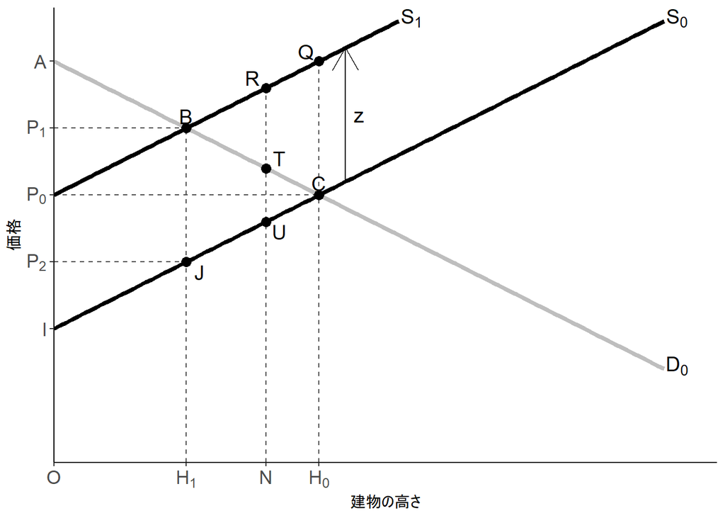

図4：負の外部性と景観権（開発受益者に付与）

それでは，建物は最終的にどこまで高くなるでしょうか？答えは，やはり社会的余剰を最大化する高さH<sub>1</sub>です．このとき，周辺住民は開発受益者の余剰の減少分（BCJ）を補償しても，面積RQCTを超える面積BQCだけの費用負担を減らすことができます．一方，開発受益者は余剰の減少分を補償されるため，建物の高さがH<sub>1</sub>であっても余剰は，面積ACIのまま維持されます．

このように，景観権をどちらに与えた場合でも，取引を通じて効率的な建物の高さが実現します．これを**コースの定理**とよびます．[^2]

しかし，冒頭で述べた高さ規制（[住宅価格と住宅政策](https://shinichiro-iwata.github.io/lecture-notes-urban-econ/housing-price-and-policy.html)の「4 政府介入 （4）負の外部性と土地利用規制」の例）を思い出してください．高さ規制によって効率的な建物の高さが実現したとしても，周辺住民の余剰は外部費用に相当する面積P<sub>0</sub>BJIだけ減少します．景観権が開発受益者に与えられた場合，周辺住民はこの負担に加え，開発受益者への補償（面積BCJ）も負担することになり，結果として費用負担が大きくなります．このような状況は，周辺住民の不満や陳情によって，建築物の開発をいっそう困難にすることが予想されます．建築物の開発を進めるためには，周辺住民との摩擦を抑える方策として，本稿で見たような高層税と補償の組み合わせや，周辺住民への景観権の付与が有力な選択肢として挙げられます．

# 参考文献

- 国立市（2023）[「国立市まちづくり条例について（概要版）」](https://www.city.kunitachi.tokyo.jp/material/files/group/52/machizyogaiyou.pdf) （アクセス日：2025-07-18）．↩︎
- 国立市（2024）[「陳情第6号 国立市の景観と市民の生活環境を守るために，都市計画とまちづくり条例の問題を解決することを求める陳情」](https://www.city.kunitachi.tokyo.jp/material/files/group/73/06chinjo6.pdf) （アクセス日：2025-07-18）．↩︎
- 日本経済新聞（2016）[「国立市，建物の高さを細かく規制 マンション乱開発に歯止め」](https://www.nikkei.com/article/DGKKZO08602380Q6A021C1L83000/)『日本経済新聞』2016年10月21日．↩︎
- 日本経済新聞（2018）[「景観守り継ぐ郊外の理想郷 国立・大学通り 今昔まち話」](https://www.nikkei.com/article/DGXMZO28545090U8A320C1CC0000/)『日本経済新聞』2018年3月24日．↩︎
- 日本経済新聞（2024）[「積水ハウス，国立のマンション解体｢富士山の眺望を優先」」](https://www.nikkei.com/article/DGXZQOUF11BX00R10C24A6000000/)『日本経済新聞』2024年6月11日．↩︎
- 八田達夫（2008）[『ミクロ経済学I 市場の失敗と政府の失敗への対策』](https://book.toyokeizai.net/textbook/book/?s=%E3%83%9F%E3%82%AF%E3%83%AD%E7%B5%8C%E6%B8%88%E5%AD%A6I)東洋経済新報社．↩︎

# R環境

**セッション情報**

- R version 4.4.3 (2025-02-28 ucrt)
  - RStudio 2025.05.1+513
  - rmarkdown_2.29

**使用したパッケージ**

- `osmdata`
- `sf`
- `tidyverse`

# リンク

[都市経済学講義ノート](https://shinichiro-iwata.github.io/lecture-notes-urban-econ/)

[Rによる地理空間データの可視化](https://shinichiro-iwata.github.io/geospatial-data-visualization/)

[Shinichiro Iwata](https://shinichiro-iwata.github.io/)

**アイコン**

Font Awesome 7

**生成AIの使用について**

ChatGPTのサービスを利用した後，内容を確認し，必要に応じて編集を行いました．

[^1]: 当該地域は近隣商業地域であるため，高さ制限はできません。そこで国立市は，国立市まちづくり条例を作成し，条例において近隣商業地域では高さを31m以内とするよう求めています．さらに，高さ20m以上の建築物は周辺環境に影響を及ぼす恐れがあるとみなし，届出や周辺住民への説明が必要とされています（日本経済新聞，2016；国立市，2023）．
[^2]: コースの定理が機能しない場合については八田（2008）第8章を参照ください．